# Análise dos gastos da câmara dos deputados

Bruno Rafael Araújo Vasconcelos

07 de abril de 2017

Consideramos aqui que se uma despesa foi feita em uma legislatura, mas só descontada da cota do deputado em um ano diferente após a legislatura, a despesa vai para o ano em que realmente foi descontada pois estamos interessados apenas em comparar os gastos entre esquerda e direita e não comparar os gastos anuais. Outra coisa importante é que consideramos apenas os gastos dos deputados titulares para esta análise, pois os valores dos deputados titulares representam bem o que exatamente vem ocorrendo com as despesas com cotas no país.

A tabela a seguir, mostra os problemas apresentados com os dados e o tratamento com eles.

[output not shown]

```r
gastos_filter <- gastos %>%
  filter(!is.na(vlrLiquido)) %>%
  filter(!is.na(numAno)) %>%
  mutate(txtDescricao = ifelse(txtDescricao == "Emissão Bilhete Aéreo", "PASSAGENS AÉREAS", txtDescricao))

gastos_filter <- gastos_filter %>%
  filter(complete.cases(gastos_filter))

gastos_parlamentares <- gastos_filter %>% filter(!txNomeParlamentar %in% unique(sgPartido)) %>%
filter(numAno < 2017 & numAno > 2008)

gastos_partido <- gastos_filter %>%
filter(txNomeParlamentar %in% unique(sgPartido)) %>%
filter(!txNomeParlamentar %in% unique(sgPartido))

nomes_titulares <- deputados %>% filter(condicao=="Titular") %>% select(nomeParlamentar)
nomes_suplentes <- deputados %>% filter(condicao=="Suplente") %>% select(nomeParlamentar)

gastos_titulares <- gastos_parlamentares %>% filter(txNomeParlamentar %in% nomes_titulares$nomeParlamentar)
gastos_suplentes <- gastos_parlamentares %>% filter(txNomeParlamentar %in% nomes_suplentes$nomeParlamentar)

rm(gastos_2009)
rm(gastos_2010)
rm(gastos_2011)
rm(gastos_2012)
rm(gastos_2013)
rm(gastos_2014)
```

## O que queremos saber?

O limite de cada cota varia de estado para estado, por exemplo o valor máximo que um deputado pode gastar em Roraima é de aproximadamente 45.000,00 enquanto que na Paraíba é de aproximadamente 42.000,00. Só que podem existir parlamentares que são mais conscientes e que para não elevar as despesas públicas preferem não usar toda a cota disponível. Será que é alto o número de deputados que fazem isso e que possuem uma ideologia? Como varia entre os partidos? Vamos tentar responder estas perguntas.

O repositório com os dados e o código usado nesta e em outras análises se encontra [aqui](https://github.com/BrunoRafael/FPCC)

## Análise

*Como funciona a variação de gastos entre direita, esquerda e centro? Em qual delas os gastos variam mais? Quem gasta mais?*

*Quais os partidos em que os deputados possuem maior diferença entre os gastos?*

*Extra1 Houveram deputados de direita, esquerda ou centro que extrapolaram o limite das cotas em 2016(ano de eleição)? E em 2015* *Extra2 Será que os gastos que houveram com partidos foram mais de esquerda ou direita?*

Nos últimos anos os deputados apresentaram mudanças significativas na forma com que usam suas cotas.Desde 2013 que houve uma espécie de “mudança de comportamento” dos parlamentares, o número de deputados que passou a gastar menos cresceu embora isso não tenho afetado muito a variação de gastos, pelo gráfico abaixo dá pra perceber um maior número de pontos escuros do lado esquerdo a partir de 2013.

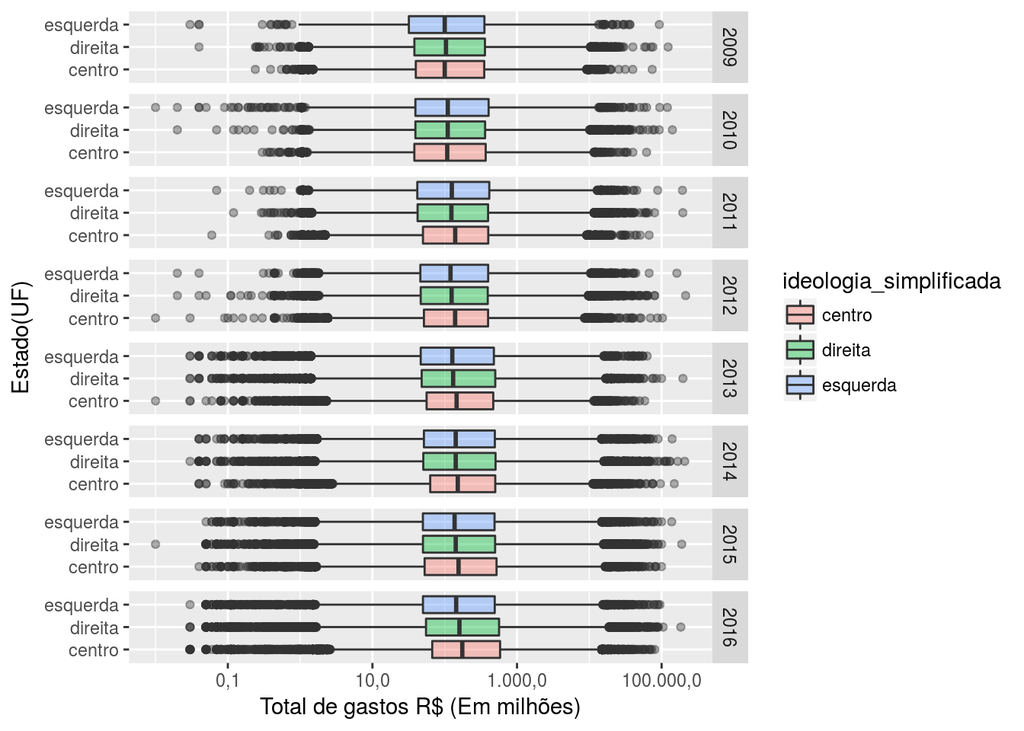

```r
gastos_titulares %>% group_by(ideologia_simplificada, numAno) %>%
filter(numAno >= 2009 & numAno < 2017) %>%
ggplot(aes(x = ideologia_simplificada, y=vlrLiquido, fill=ideologia_simplificada)) +
geom_boxplot(alpha = 0.4)+
scale_y_log10(labels=formata_label)+
facet_grid(numAno ~ .)+
labs(x="Estado(UF)", y = "Total de gastos R$ (Em milhões)")+
coord_flip()
```

Para termos uma visão melhor vamos observar a distância entre o maior e o menor valor representativo de cada gráfico. A estatística distância interquartil, abrange 50% de todos os valores das notas fiscais dos deputados. A variação de gastos, determinada pela estatística IQR vem aumentando para o centro desde 2012. Isto significa que os gastos dos deputados que se declaram de centro estão variando a cada ano. Já para a esquerda, a variação se manteve praticamente constante desde 2013. Veja o gráfico abaixo.

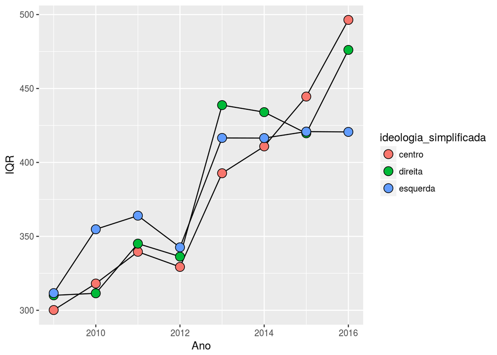

```r
gastos_titulares %>% group_by(ideologia_simplificada, numAno) %>%
filter(numAno >= 2009 & numAno < 2017) %>%
summarise(IQR = IQR(vlrLiquido)) %>%
ggplot(aes(x=numAno, y=IQR, fill=ideologia_simplificada)) +
geom_line() + geom_point(size=4, shape=21)+
labs(x="Ano")
```

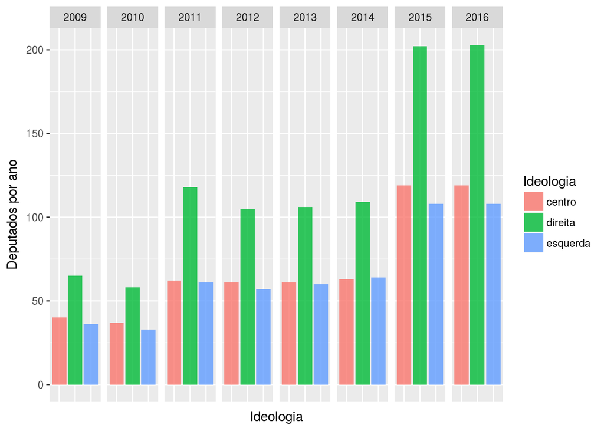

```r
g <- gastos_titulares %>%
  group_by(txNomeParlamentar, ideologia_simplificada, numAno) %>%
  summarise(Total = sum(vlrLiquido))

g %>% group_by(ideologia_simplificada, numAno) %>%
filter(numAno < 2017 & numAno >= 2009) %>%
ggplot(aes(x = as.factor(ideologia_simplificada), fill=as.factor(ideologia_simplificada))) +
geom_histogram(stat = "count", alpha=0.8) +
facet_grid(.~numAno)+
scale_y_continuous(labels=formata_label)+
theme(axis.text.x=element_blank(),
        axis.ticks.x=element_blank())+
labs(x="Ideologia", y = "Deputados por ano", fill="Ideologia")
```

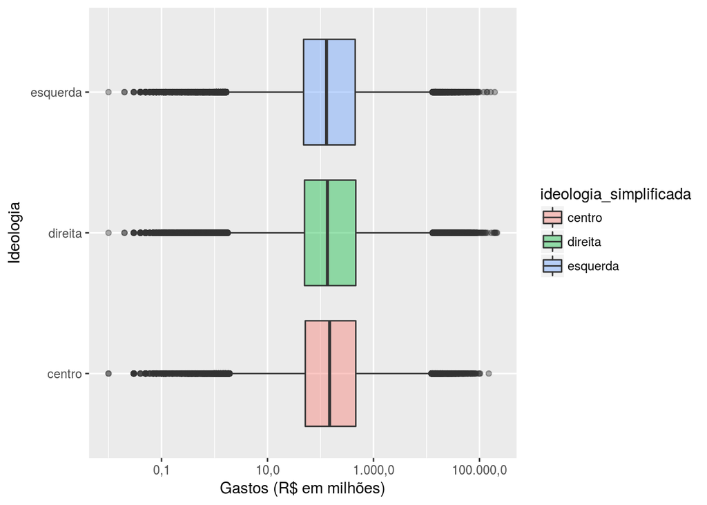

```r
gastos_titulares %>% group_by(ideologia_simplificada) %>%
filter(numAno < 2017 & numAno >= 2009) %>%
ggplot(aes(x = ideologia_simplificada, y=vlrLiquido, fill=ideologia_simplificada)) +
geom_boxplot(alpha = 0.4)+
scale_y_log10(labels=formata_label)+
labs(x = "Ideologia", y = "Gastos (R$ em milhões)")+
coord_flip()
```

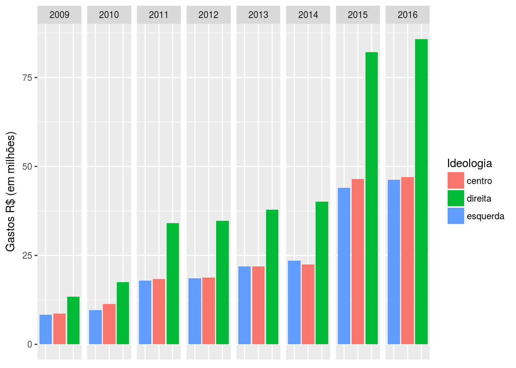

```r
gastos_titulares %>% group_by(ideologia_simplificada, numAno) %>%
filter(numAno < 2017 & numAno >= 2009) %>%
summarise(Total = sum(vlrLiquido)/1000000) %>%
ggplot(aes(x = reorder(as.factor(ideologia_simplificada), Total), y=Total, fill=as.factor(ideologia_simplificada))) +
geom_histogram(stat = "identity") +
facet_grid(.~numAno)+
labs(y = "Gastos R$ (em milhões)", fill="Ideologia")+
theme(axis.text.x=element_blank(),
        axis.ticks.x=element_blank(),
      axis.title.x=element_blank())
```

A descoberta mais importante feita nessa análise talvez seja a de que os gastos com os deputados tem aumentado a cada ano. O que era de se esperar é que fosse diminuindo, devido a crise econômica que o país atravessa, porém esse gráfico demonstra que está aumentando. O comprimento do retangulo representa todos os gastos desde 2009. Esse retangulo é *fatiado* e cada fatia é a representação proporcional dos gastos de cada ano. Este crescimento ocorreu para todos os casos, centro, esquerda e direita.

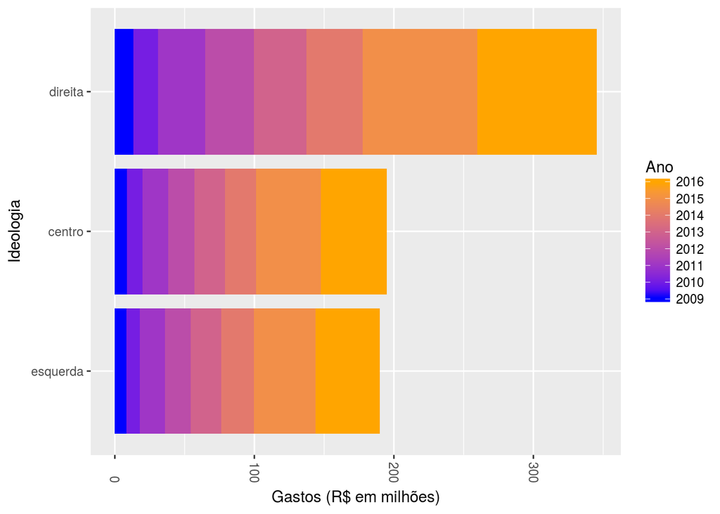

```r
gastos_titulares %>%
group_by(ideologia_simplificada, numAno) %>%
filter(numAno < 2017 & numAno >= 2009) %>%
summarise(total=sum(vlrLiquido)/1000000) %>%
arrange(numAno) %>%
ggplot(mapping = aes(x = reorder(ideologia_simplificada, total), y=total, fill = numAno)) + geom_bar(stat = "identity") +
coord_flip()+
theme(axis.text.x=element_text(angle=-90,hjust=1,vjust=0.5))+
labs(x = "Ideologia", y = "Gastos (R$ em milhões)", fill="Ano")+ scale_fill_continuous(breaks=unique(gastos_titulares$numAno), low="blue", high="orange")
```

## Avaliando os partidos

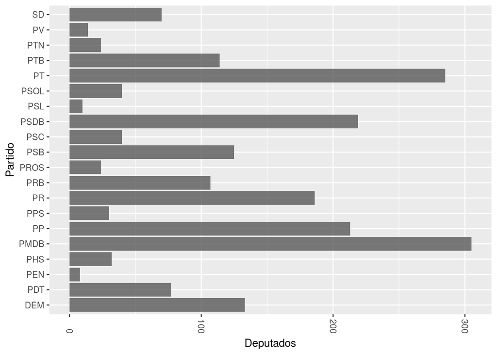

```r
g <- gastos_titulares %>%
  group_by(txNomeParlamentar, sgPartido, numAno) %>%
  summarise(Total = sum(vlrLiquido))

g %>% group_by(sgPartido, numAno) %>%
filter(numAno < 2017 & numAno >= 2009) %>%
ggplot(aes(x = as.factor(sgPartido))) +
geom_histogram(stat = "count", alpha=0.8) +
scale_y_continuous(labels=formata_label)+
theme(axis.text.x=element_text(angle=-90,hjust=1,vjust=0.5))+
labs(x="Partido", y = "Deputados", fill="Ideologia")+
coord_flip()
```

Avaliando o IQR que mede o nível de variação dos gastos, o partido que apresentou maior variação de gastos foi o PROS, seguido de SD, PTB e PDT. Quanto maior o IQR, maior será o intervalo em que os gastos se encontram para 50% dos deputados.

```
## geom_path: Each group consists of only one observation. Do you need to
## adjust the group aesthetic?
```

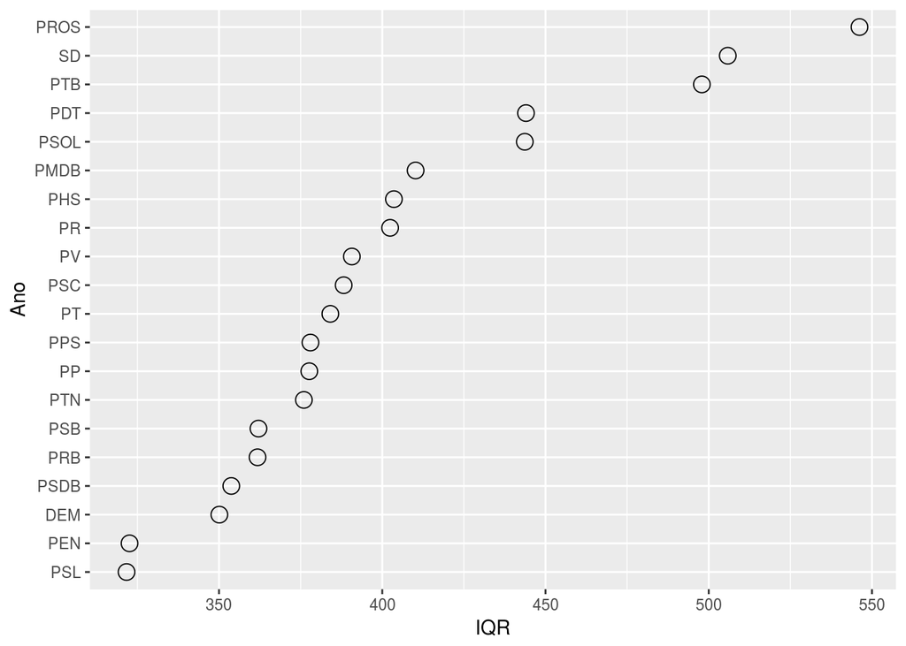

```r
gastos_titulares %>% group_by(sgPartido) %>%
filter(numAno >= 2009 & numAno < 2017) %>%
summarise(IQR = IQR(vlrLiquido)) %>%
ggplot(aes(x=reorder(sgPartido, IQR), y=IQR)) +
geom_line() + geom_point(size=4, shape=21)+
labs(x="Ano")+
coord_flip()
```

## Novas perguntas

Vamos agora dar uma olhada na extrapolação das cotas dos deputados segundo a sua ideologia. Será que direita, esquerda e centro vem extrapolando esses limites?

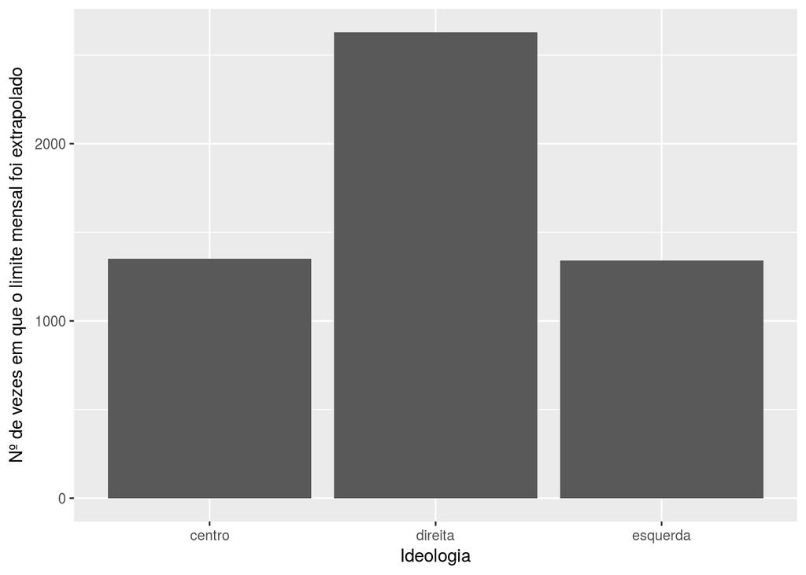

```r
gastos_titulares %>%
  group_by(txNomeParlamentar, sgUF, ideologia_simplificada, numMes, numAno) %>%
  summarise(Total = sum(vlrLiquido)) %>%
  right_join(cotas_por_estado, c("sgUF" = "estado")) %>%
  filter(Total > valor)%>%
  ggplot(aes(x=factor(ideologia_simplificada))) +
  geom_histogram(stat = "count")+
  labs(x="Ideologia", y="Nº de vezes em que o limite mensal foi extrapolado")
```

E a resposta é sim! Parece ser uma coisa comum os deputados ultrapassarem os limites de suas cotas. O ano de 2016 foi o ano em que mais isso ocorreu. E mais uma vez os deputados que fazem parte de partidos de direita fizeram com mais frequencia. Mais uma vez a quantidade de deputados a mais que a esquerda e o centro pode fazer a diferença.

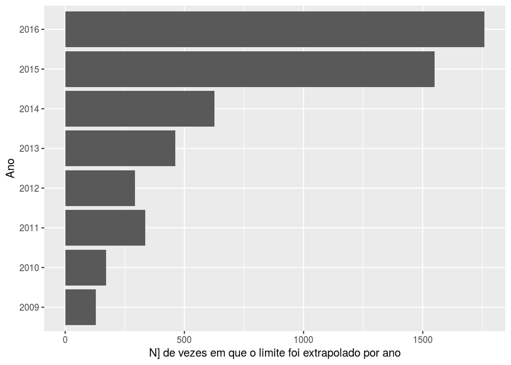

```r
gastos_titulares %>%
  group_by(txNomeParlamentar, sgUF, ideologia_simplificada, numMes, numAno) %>%
  summarise(Total = sum(vlrLiquido)) %>%
  right_join(cotas_por_estado, c("sgUF" = "estado")) %>%
  filter(Total > valor)%>%
  ggplot(aes(x=factor(numAno))) +
  geom_histogram(stat = "count")+
  labs(x="Ano", y="N] de vezes em que o limite foi extrapolado por ano")+
  coord_flip()
```

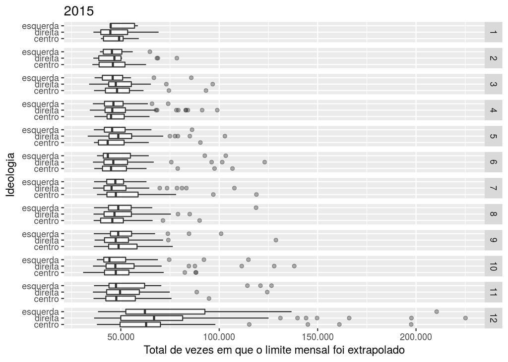

```r
gastos_titulares %>%
  group_by(txNomeParlamentar, sgUF, ideologia_simplificada, numAno, numMes) %>%
  filter(numAno == 2015) %>%
  summarise(Total = sum(vlrLiquido)) %>%
  right_join(cotas_por_estado, c("sgUF" = "estado")) %>%
  filter(Total > valor)%>%
  ggplot(aes(x = ideologia_simplificada, y=Total)) +
  geom_boxplot(alpha = 0.4)+
  ggtitle("2015")+
  facet_grid(numMes~.)+
  labs(x="Ideologia", y="Total de vezes em que o limite mensal foi extrapolado")+
  scale_y_continuous(labels=formata_label)+
  coord_flip()
```

## Avaliando os gastos considerados do partido e não do parlamentar